# IODS Course Project

Pinja-Liina Jalkanen

# About the Project

This is my personal project page for the University of Helsinki statistics course named “Introduction to Open Data Science”.

# About Me

My name is Pinja-Liina Jalkanen.

Please be forewarned that my statistics skills are rather crappy and usually limited to some simple descriptives and regressions. I do know some tech stuff quite well, though, so I don’t expect great difficulties with the R syntax, Git or the like. Kimmo Vehkalahti said on the first course lesson that data analysis is often 90% preparation of the data and 10% doing the analysis. I don’t know about the weighing on this course, but I usually don’t need help with the 90% at all; that’s mostly like, [RTFM, STFW and the like](https://en.wikipedia.org/wiki/RTFM) anyway.

With regard to the 10% though, I don’t trust my skills at all.

Link to this project: https://github.com/pinjaliina/IODS-project

# Analysis of the Learning Questionnaire

## Introduction

The data of the analysis in this exercise was the Autumn 2014 Introductory Statistics Course Learning Questionnaire. The data has 60 variables and 183 observations; except for the few background related variables (age, attitude towards statistics, course points), most of the questions were learning-related questions with answers given on Likert scale, from 1 to 5.

For the analysis, I’ve averaged the variables related to deep learning, surface learning, and strategic learning. (For the initial data wrangling part of this exercise, see [this R script](https://github.com/pinjaliina/IODS-project/blob/master/data/create_learning2014.R)).

## Overview of the Data

The data is read in as follows:

```r
# Read in the data
lrn2014a <- as.data.frame(read.table('data/learning2014.csv',  sep="\t", header=TRUE))
```

A scatter plot matrix of the variables of the data can be drawn as follows, coloured by the gender variable:

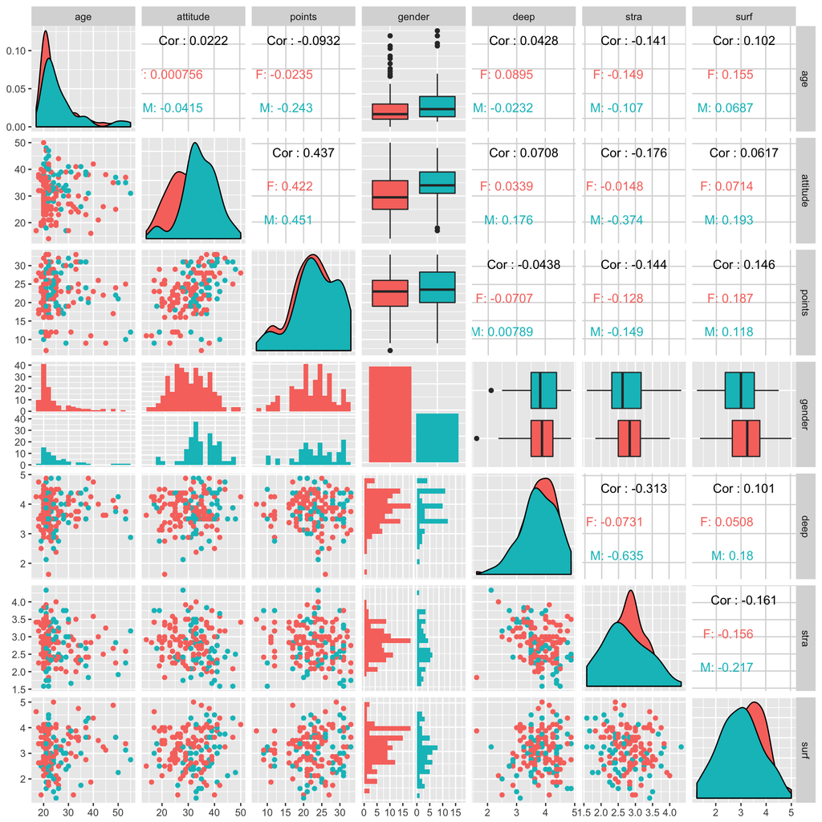

```r
p <- ggpairs(lrn2014a, mapping = aes(col = gender), lower = list(combo = wrap("facethist", bins = 20)))
p
```

A summary of each of the variables of the data can be displayed as follows:

```r
summary(lrn2014a)
```

```
##       age           attitude         points      gender
##  Min.   :17.00   Min.   :14.00   Min.   : 7.00   F:110
##  1st Qu.:21.00   1st Qu.:26.00   1st Qu.:19.00   M: 56
##  Median :22.00   Median :32.00   Median :23.00
##  Mean   :25.51   Mean   :31.43   Mean   :22.72
##  3rd Qu.:27.00   3rd Qu.:37.00   3rd Qu.:27.75
##  Max.   :55.00   Max.   :50.00   Max.   :33.00
##       deep            stra            surf
##  Min.   :1.625   Min.   :1.583   Min.   :1.250
##  1st Qu.:3.500   1st Qu.:2.417   1st Qu.:2.625
##  Median :3.875   Median :2.833   Median :3.188
##  Mean   :3.796   Mean   :2.787   Mean   :3.121
##  3rd Qu.:4.250   3rd Qu.:3.167   3rd Qu.:3.625
##  Max.   :4.875   Max.   :4.333   Max.   :5.000
```

As can be seen from the output, most of the variables – with the exception of the age of the students – are distributed quite randomly and only correlate weakly with the course points. The most significant exception is the attitude towards statistics, which correlates more strongly with the course points than any other variable. Except for the age and points, the distribution of most of the variables seems to be reasonably close to normal distribution. The gender variable demonstrates that the course was attended by significantly more female than male students.

## Fitting of a Regression Model

A linear regression model can be fit to the data as follows:

```r
lrn2014_model <- lm(points ~ attitude + stra + surf, data = lrn2014a)
```

The chosen explanatory variables for the model were attitude, strategic learning and surface learning. The summary of the model can be printed as follows:

```r
summary(lrn2014_model)
```

```
##
## Call:
## lm(formula = points ~ attitude + stra + surf, data = lrn2014a)
##
## Residuals:
##      Min       1Q   Median       3Q      Max
## -17.1550  -3.4346   0.5156   3.6401  10.8952
##
## Coefficients:
##             Estimate Std. Error t value Pr(>|t|)
## (Intercept) 11.01711    3.68375   2.991  0.00322 **
## attitude     0.33952    0.05741   5.913 1.93e-08 ***
## stra        -0.58607    0.80138  -0.731  0.46563
## surf         0.85313    0.54159   1.575  0.11716
## ---
## Signif. codes:
## 0 '***' 0.001 '**' 0.01 '*' 0.05 '.' 0.1 ' ' 1
##
## Residual standard error: 5.296 on 162 degrees of freedom
## Multiple R-squared:  0.2074, Adjusted R-squared:  0.1927
## F-statistic: 14.13 on 3 and 162 DF,  p-value: 3.156e-08
```

```r
lrn2014_model <- lm(points ~ attitude + surf, data = lrn2014a)
summary(lrn2014_model)
```

```
##
## Call:
## lm(formula = points ~ attitude + surf, data = lrn2014a)
##
## Residuals:
##      Min       1Q   Median       3Q      Max
## -17.6436  -3.3113   0.5575   3.7928  10.9295
##
## Coefficients:
##             Estimate Std. Error t value Pr(>|t|)
## (Intercept)  8.97290    2.39591   3.745  0.00025 ***
## attitude     0.34658    0.05652   6.132 6.31e-09 ***
## surf         0.91365    0.53447   1.709  0.08927 .
## ---
## Signif. codes:
## 0 '***' 0.001 '**' 0.01 '*' 0.05 '.' 0.1 ' ' 1
##
## Residual standard error: 5.289 on 163 degrees of freedom
## Multiple R-squared:  0.2048, Adjusted R-squared:  0.1951
## F-statistic: 20.99 on 2 and 163 DF,  p-value: 7.734e-09
```

## Analysis of the Summary

With the removal of that value the statistical significance of the surface learning estimates improves somewhat to near significant levels and can be left to the model. In practice its effect to the model is so tiny that it nearly as well be left out, but because it is reasonably close to statistical significance *and* also gives highest adjusted R<sup>2</sup> value – the adjusted R<sup>2</sup> of a model where attitude is the only explanatory variable as reported by `summary()` would be 0.1856 – its inclusion to the model is justified.

While the model estimates are statistically significant, the model as a whole is not very good: the multiple R<sup>2</sup> value is only 0.20, which means that about 80 % of the relationship between the dependent variable – course points – and the explanatory variables remains unexplained. Thus, any predictions based on the model alone might not be very reliable.

## Diagnostic Plots and Assumptions of the Model

In addition to linearity, linear models are fitted with the assumption that:

1. The errors of the model are normally distributed.
2. The errors are not correlated.
3. The size of the errors does not depend on the explanatory variables.

The validity of these assumption can be tested by analysing the residuals of the model. This can be done with the help of different kinds of diagnostic plots. In the following figure three different plots are drawn:

- A residuals vs. fitted values plot
- A Q–Q-plot
- A Residuals vs. leverage plot

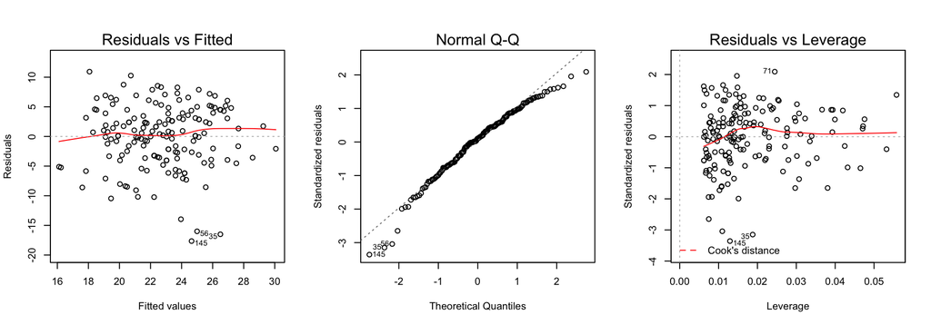

```r
par(mfrow = c(1,3)) # Set some graphical params.
# It seems that the drawing order of the plot is independent of the vector
# order and can't be changed.
plot(lrn2014_model, which = c(1,2,5))
```

Interpretation of the plots:

1. The Q–Q-plot demonstrates that the standardised residuals of the model fit to the theoretical quantities reasonably well, so the normal distribution assumption is valid.
2. The residuals vs. fitted values plot doesn’t show any kind of pattern, so the errors are not correlated and their size is independent of the explanatory variables (their σ<sup>2</sup> is constant).
3. In addition to checking the abovementioned assumptions, it is recommended to check that no single observation has an oversized effect on the model, because these might distort the model coefficients. As the x-axis scale of the residuals vs. leverage plot is relatively narrow with no significant outliers, we can conclude that the model is not distorted by any single observation.

# Analysis of Alcohol Consumption

## Introduction

The data of the analysis in this exercise was Fabio Pagnotta’s and Hossain Mohammad Amran’s Using Data Mining To Predict Secondary School Student Alcohol Consumption (2008), published by Department of Computer Science of the University of Camerino ([link: https://archive.ics.uci.edu/ml/datasets/STUDENT+ALCOHOL+CONSUMPTION](https://archive.ics.uci.edu/ml/datasets/STUDENT+ALCOHOL+CONSUMPTION)). For the analysis, I’ve also created a combined total alcohol consumption variable (sum of weekday and weekend consumption) and created a separate logical high use variable, based on the total consumption. (For the initial data wrangling part of this exercise, see [this R script](https://github.com/pinjaliina/IODS-project/blob/master/data/create_alc.R)).

## Overview of the Data

The data is read in as follows:

```r
# Read in the data
alc <- as.data.frame(read.table('data/alc.csv',  sep="\t", header=TRUE))
```

A glimpse of all of the variables of the data can be displayed as follows:

```r
glimpse(alc)
```

```
## Observations: 382
## Variables: 35
## $ school     <fctr> GP, GP, GP, GP, GP, GP, GP, GP, GP, GP, GP, G...
## $ sex        <fctr> F, F, F, F, F, M, M, F, M, M, F, F, M, M, M, ...
## $ age        <int> 18, 17, 15, 15, 16, 16, 16, 17, 15, 15, 15, 15...
## $ address    <fctr> U, U, U, U, U, U, U, U, U, U, U, U, U, U, U, ...
## $ famsize    <fctr> GT3, GT3, LE3, GT3, GT3, LE3, LE3, GT3, LE3, ...
## $ Pstatus    <fctr> A, T, T, T, T, T, T, A, A, T, T, T, T, T, A, ...
## $ Medu       <int> 4, 1, 1, 4, 3, 4, 2, 4, 3, 3, 4, 2, 4, 4, 2, 4...
## $ Fedu       <int> 4, 1, 1, 2, 3, 3, 2, 4, 2, 4, 4, 1, 4, 3, 2, 4...
## $ Mjob       <fctr> at_home, at_home, at_home, health, other, ser...
## $ Fjob       <fctr> teacher, other, other, services, other, other...
## $ reason     <fctr> course, course, other, home, home, reputation...
## $ nursery    <fctr> yes, no, yes, yes, yes, yes, yes, yes, yes, y...
## $ internet   <fctr> no, yes, yes, yes, no, yes, yes, no, yes, yes...
```

[output cut: 22 more lines]

## Purpose of the Analysis

As can be seen from the above variable list, there are both numerical and factorial background variables. The target variable for this analysis is the binary high/low alcohol consumption variable. To analyse that, I’ve chosen the following four variables that I assume are indicative of students’ alcohol consumption:

1. Absence of lessons (variable absence). I assume that students who skip lessons drink a lot drink more.
2. Going out (variable goout). I assume that students who go out more do so to drink, so they drink more.
3. Final grade (variable G3). I assume that students with poor grades drink more.
4. Study time (variable studytime). I assume that students who spend less time studying spend more time drinking.

```r
summary(alc[c('absences','goout','G3','studytime')])
```

```
##     absences          goout             G3          studytime
##  Min.   : 0.000   Min.   :1.000   Min.   : 0.00   Min.   :1.000
##  1st Qu.: 0.000   1st Qu.:2.000   1st Qu.: 8.00   1st Qu.:1.000
##  Median : 3.000   Median :3.000   Median :11.00   Median :2.000
##  Mean   : 5.319   Mean   :3.113   Mean   :10.39   Mean   :2.034
##  3rd Qu.: 8.000   3rd Qu.:4.000   3rd Qu.:14.00   3rd Qu.:2.000
##  Max.   :75.000   Max.   :5.000   Max.   :20.00   Max.   :4.000
```

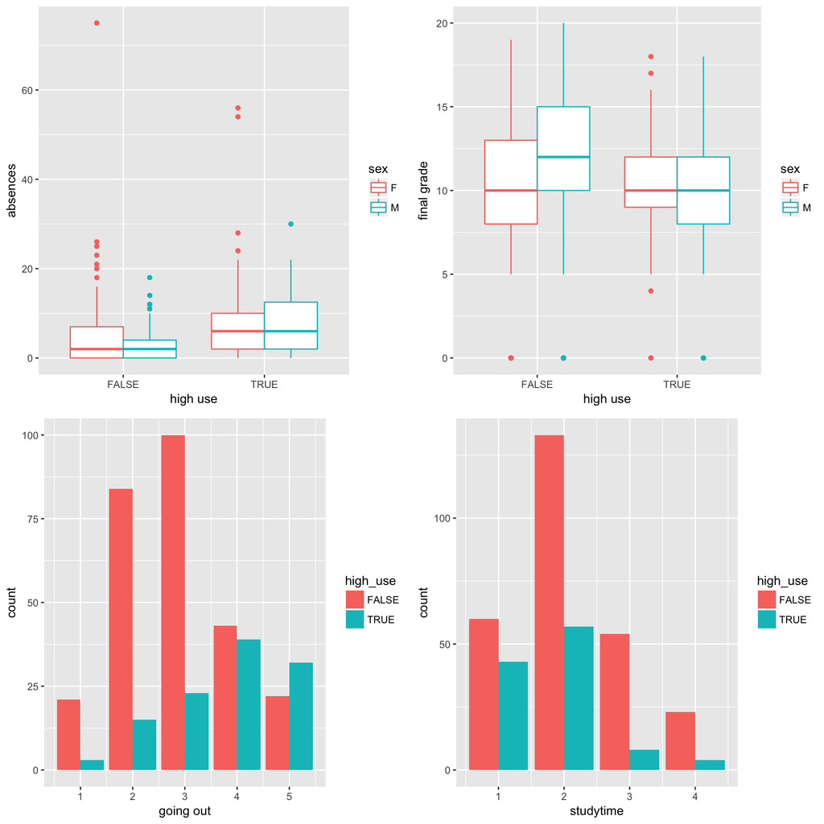

```r
p1 <- ggplot(alc, aes(x = high_use, y = absences, col=sex)) + geom_boxplot() + xlab('high use')
p2 <- ggplot(alc, aes(goout)) + geom_bar(aes(fill = high_use), position = "dodge", stat="count") + xlab('going out')
p3 <- ggplot(alc, aes(x = high_use, y = G3, col=sex)) + geom_boxplot() + ylab('final grade') + xlab('high use')
p4 <- ggplot(alc, aes(studytime)) + geom_bar(aes(fill = high_use), position = "dodge", stat="count")
# The multiplot() is defined in the init section of this file. For details, see
# http://www.cookbook-r.com/Graphs/Multiple_graphs_on_one_page_(ggplot2)/
multiplot(p1, p2, p3, p4, cols = 2)
```

## Logistic Regression Analysis

Based on the above exploration of the variables, it looks like all my previously stated hypothetical assumptions were true to at least some extent, with perhaps the exception of final grade. To confirm this, I did a logistic regression analysis using my chosen variables as the explanatory variables.

In the following, a model is fitted to the data and summarised.

```r
m <- glm(high_use ~ absences + goout + G3 + studytime, data = alc, family = "binomial")
summary(m)
```

```
##
## Call:
## glm(formula = high_use ~ absences + goout + G3 + studytime, family = "binomial",
##     data = alc)
##
## Deviance Residuals:
##     Min       1Q   Median       3Q      Max
## -1.8166  -0.7495  -0.5034   0.8071   2.5083
##
## Coefficients:
##             Estimate Std. Error z value Pr(>|z|)
## (Intercept) -2.62195    0.62727  -4.180 2.92e-05 ***
## absences     0.05600    0.01643   3.407 0.000656 ***
## goout        0.74536    0.12013   6.204 5.49e-10 ***
## G3           0.01269    0.02848   0.446 0.655854
## studytime   -0.60004    0.16852  -3.561 0.000370 ***
## ---
## Signif. codes:  0 '***' 0.001 '**' 0.01 '*' 0.05 '.' 0.1 ' ' 1
##
## (Dispersion parameter for binomial family taken to be 1)
##
##     Null deviance: 462.21  on 381  degrees of freedom
## Residual deviance: 383.16  on 377  degrees of freedom
## AIC: 393.16
##
## Number of Fisher Scoring iterations: 4
```

By the model summary, it looks like my hypothesis was wrong with regard the final grade, which wasn’t a good predictor at all of high alcohol consumption: it bears no statistical significance whatsoever to it. All the other chosen explanatory variables are relatively strong predictors. Calculating the odds ratios hints to the same direction:

```r
or <- exp(coef(m))
or
```

```
## (Intercept)    absences       goout          G3   studytime
##  0.07266094  1.05759534  2.10719756  1.01277150  0.54879019
```

As shown by the odds ratios, a student has virtually the same likelihood to consume much alcohol regardless of the grade. Interestingly, the absences are not much of a factor either: a student with lot of absences is only 1.06 times more likely to consume a lot of alcohol. With regard outgoingness and studytime the results are, however, very clear: a student who goes out a lot is two times more likely to also drink a lot. Same goes for studytime: a student who studies a lot is almost half less likely to drink a lot. But while absence doesn’t increase the likelihood of high use a lot, comparing its odd ratio to its confidence interval still confirms its statistical significance:

```r
ci <- exp(confint(m))
cbind(or, ci)
```

```
##                     or      2.5 %    97.5 %
## (Intercept) 0.07266094 0.02042166 0.2402599
## absences    1.05759534 1.02602413 1.0954317
## goout       2.10719756 1.67554867 2.6863511
## G3          1.01277150 0.95846241 1.0720167
## studytime   0.54879019 0.38995929 0.7564410
```

As shown by the confidence intervals of the odd ratios, the confidence intervals of all the other explanatory variables except that of final grade (G3) steer well clear of one, which means that the likelihoods that the odds predicted by them are low. With regard the final grade, however, my initial hypothesis was clearly wrong because the value one is almost in the middle of its confidence interval. Thus, before making any actual predictions using the model, it’s best to refit it without that variable:

```r
m <- glm(high_use ~ absences + goout + studytime, data = alc, family = "binomial")
summary(m)
```

```
##
## Call:
## glm(formula = high_use ~ absences + goout + studytime, family = "binomial",
##     data = alc)
##
## Deviance Residuals:
##     Min       1Q   Median       3Q      Max
## -1.8376  -0.7530  -0.4927   0.8091   2.4967
##
## Coefficients:
##             Estimate Std. Error z value Pr(>|z|)
## (Intercept) -2.47603    0.53168  -4.657 3.21e-06 ***
## absences     0.05627    0.01651   3.409 0.000651 ***
## goout        0.73711    0.11835   6.228 4.72e-10 ***
## studytime   -0.59422    0.16800  -3.537 0.000405 ***
## ---
## Signif. codes:  0 '***' 0.001 '**' 0.01 '*' 0.05 '.' 0.1 ' ' 1
##
## (Dispersion parameter for binomial family taken to be 1)
##
##     Null deviance: 462.21  on 381  degrees of freedom
## Residual deviance: 383.36  on 378  degrees of freedom
## AIC: 391.36
##
## Number of Fisher Scoring iterations: 4
```

```r
cbind(exp(coef(m)), exp(confint(m)))
```

```
##                             2.5 %    97.5 %
## (Intercept) 0.08407616 0.02874986 0.2322992
## absences    1.05788483 1.02622976 1.0958710
## goout       2.08988646 1.66701101 2.6539672
## studytime   0.55199236 0.39259400 0.7600378
```

As shown by the above statistics, the remaining explanatory variables are now all statistically highly significant and have confidence intervals well clear of the value one, so the model is now ready to be used for predictions.

## Predicting with the Model

The model can be used for predictions as follows:

```r
# Predict the probability.
probabilities <- predict(m, type = "response")
# Add the probabilities to alc.
alc <- mutate(alc, probability = probabilities)
# Calculate a logical high use value based on probabilites.
alc <- mutate(alc, prediction = probability > 0.5)
# Tabulate the target variable versus the predictions,
# with both absolute and proportional numbers.
tbl <- table(high_use = alc$high_use, prediction = alc$prediction)
addmargins(tbl)
```

```
##         prediction
## high_use FALSE TRUE Sum
##    FALSE   246   24 270
##    TRUE     66   46 112
##    Sum     312   70 382
```

```r
round(addmargins(prop.table(tbl)), 2)
```

```
##         prediction
## high_use FALSE TRUE  Sum
##    FALSE  0.64 0.06 0.71
##    TRUE   0.17 0.12 0.29
##    Sum    0.82 0.18 1.00
```

As the tables show, the model is too careful in its predictions; it predicts less occurrences of high use than what the actual data shows. This can also be demonstrated graphically:

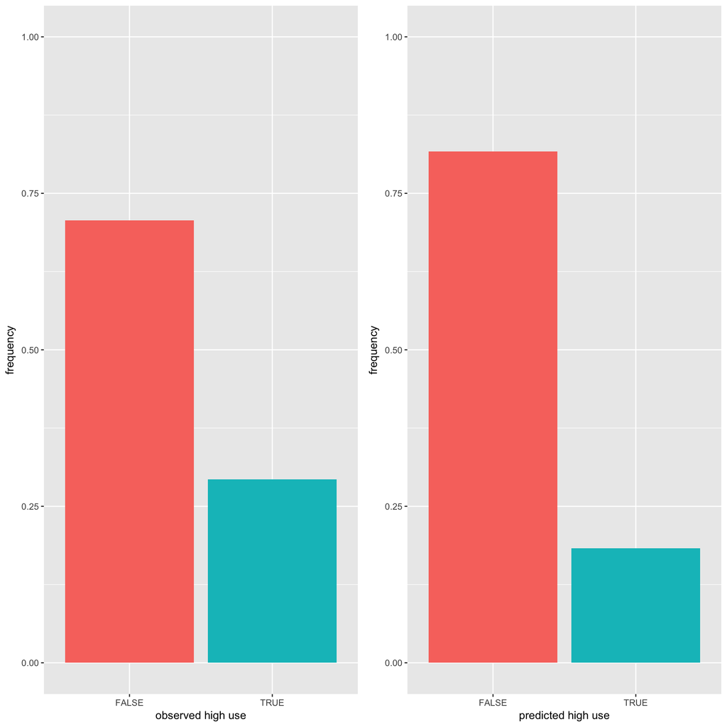

```r
hu <- as.data.frame(prop.table(table(alc$high_use)))
pred <- as.data.frame(prop.table(table(alc$prediction)))
pp1 <- ggplot(hu, aes(Var1, Freq)) + geom_col(aes(fill = Var1)) + scale_y_continuous(limits = 0:1) + ylab('frequency') + xlab('observed high use') + theme(legend.position = 'none')
pp2 <- ggplot(pred, aes(Var1, Freq)) + geom_col(aes(fill = Var1)) + scale_y_continuous(limits = 0:1) + ylab('frequency') + xlab('predicted high use') + theme(legend.position = 'none')
multiplot(pp1, pp2, cols = 2)
```

The actual model training error can be calculated as follows (note that this is a function only because one is needed later on for cv.glm()):

```r
mloss <- function(obs, prob) {
  res <- ifelse(prob > 0.5, 1, 0)
  mean(res != obs)
}
round(mloss(obs = alc$high_use, prob = alc$probability), 2)
```

```
## [1] 0.24
```

The training error is 24%, thus the model has a little over 75% accuracy. This isn’t perfect, but likely still better than any simple guessing strategy, given that by guessing alone I wasn’t able to predict my chosen variables’ statistical significance correctly.

## Cross-validation (bonus task)

To test the model further, cross-validation can be performed. The following performs a 10-fold cross-validation:

```r
cv <- cv.glm(data = alc, cost = mloss, glmfit = m, K = 10)
cv$delta[1] # Print the average number of wrong predictions.
```

```
## [1] 0.2329843
```

The average training error of the 10-fold cross-validation is 0.23, which is already better performance than [the model introduced in the DataCamp exercise](https://campus.datacamp.com/courses/helsinki-open-data-science/logistic-regression?ex=16) has. However, the model could be improved further by adding more variables. This model, however, does not include sex as a variable, while according to the DataCamp exercise it is a statistically significant variable. Thus, we could try adding it and run the cross-validation to further improve the model:

```r
m2 <- glm(high_use ~ absences + goout + studytime + sex, data = alc, family = "binomial")
summary(m2) # Summarise the model.
```

```
##
## Call:
## glm(formula = high_use ~ absences + goout + studytime + sex,
##     family = "binomial", data = alc)
##
## Deviance Residuals:
##     Min       1Q   Median       3Q      Max
## -1.7586  -0.7653  -0.4897   0.7254   2.5996
##
## Coefficients:
##             Estimate Std. Error z value Pr(>|z|)
## (Intercept) -3.23486    0.59934  -5.397 6.76e-08 ***
## absences     0.06269    0.01687   3.716 0.000202 ***
## goout        0.74151    0.12061   6.148 7.86e-10 ***
## studytime   -0.45081    0.17155  -2.628 0.008594 **
## sexM         0.81167    0.26937   3.013 0.002585 **
## ---
## Signif. codes:  0 '***' 0.001 '**' 0.01 '*' 0.05 '.' 0.1 ' ' 1
##
## (Dispersion parameter for binomial family taken to be 1)
##
##     Null deviance: 462.21  on 381  degrees of freedom
## Residual deviance: 374.08  on 377  degrees of freedom
## AIC: 384.08
##
## Number of Fisher Scoring iterations: 4
```

```r
cbind(exp(coef(m2)), exp(confint(m2))) # Count odds and their confidence intervals.
```

```
##                            2.5 %    97.5 %
## (Intercept) 0.0393658 0.01172067 0.1236057
## absences    1.0646959 1.03217181 1.1038908
## goout       2.0990949 1.66738691 2.6783765
## studytime   0.6371102 0.45038109 0.8845879
## sexM        2.2516753 1.33375527 3.8439285
```

```r
# Predict the probability.
probabilities2 <- predict(m2, type = "response")
# Add the probabilities to alc.
alc <- mutate(alc, probability2 = probabilities2)
# Calculate a logical high use value based on probabilites.
alc <- mutate(alc, prediction2 = probability2 > 0.5)
# Re-run cross-validation and print the average number of wrong predictions.
cv2 <- cv.glm(data = alc, cost = mloss, glmfit = m2, K = 10)
cv2$delta[1]
```

```
## [1] 0.2068063
```

The average training error is now only 0.21, thus clearly lower than in the previous model.